# Cyclistic bike-share analysis case study

### popular routes by casual users

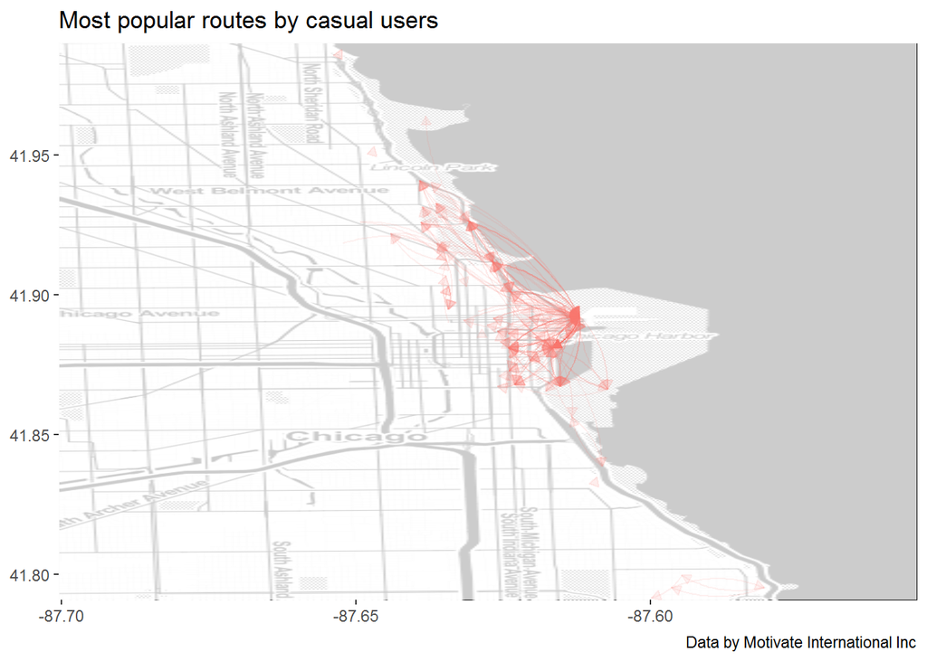

```r
ggmap(chicago_stamen,darken = c(0.8, "white")) +
 geom_curve(casual, mapping = aes(x = start_lng, y = start_lat, xend = end_lng, yend = end_lat, alpha= total, color=customer_type), size = 0.5, curvature = .2,arrow = arrow(length=unit(0.2,"cm"), ends="first", type = "closed")) +
    coord_cartesian() +
    labs(title = "Most popular routes by casual users",x=NULL,y=NULL, color="User type", caption = "Data by Motivate International Inc") +
    theme(legend.position="none")
```

### popular routes by member users

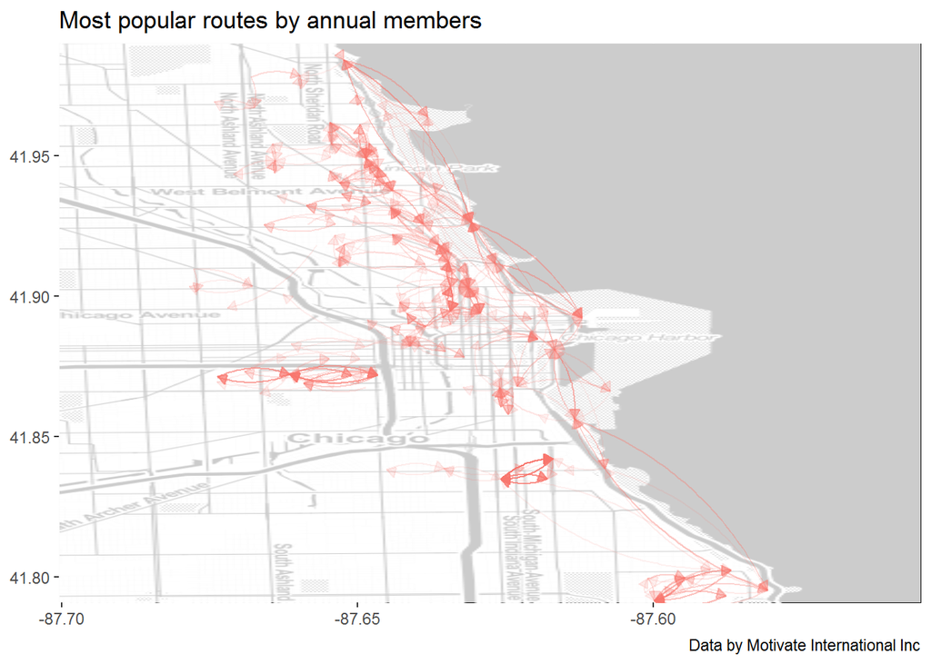

```r
ggmap(chicago_stamen,darken = c(0.8, "white")) +
    geom_curve(member, mapping = aes(x = start_lng, y = start_lat, xend = end_lng, yend = end_lat, alpha= total, color=customer_type), size = 0.5, curvature = .2,arrow = arrow(length=unit(0.2,"cm"), ends="first", type = "closed")) +
    coord_cartesian() +
    labs(title = "Most popular routes by annual members",x=NULL,y=NULL, caption = "Data by Motivate International Inc") +
    theme(legend.position="none")
```

#### selecting data

drop name of station end and start and coordinates because we don’t need them more in processing or analyzing stage

**we can make more segmentation**  
1. seg1 for customer_type,bicycle_type,ride_id  
2. seg2 customer_type,started_at,ended_at,ride_id 3. seg3 for start_station_id and end_station_id,ride_id

```r
annualtrip <- annualtrip[ -c(5,7,9:12) ]
colnames(annualtrip)
```

```
## [1] "ride_id"          "bicycle_type"     "started_at"       "ended_at"
## [5] "start_station_id" "end_station_id"   "customer_type"
```

##mutate date add two important cols that help us ride_length,week_of_day and ordered this depend on levels order not alphabet

```r
annualtrip <- annualtrip %>% mutate(ride_length_min = as.integer( round( (ended_at-started_at)/60) ))
annualtrip <- annualtrip %>% mutate(Week_Of_Day = weekdays(started_at,FALSE) )
annualtrip <- annualtrip %>% mutate(month = months.Date(started_at,FALSE) )
annualtrip$month <- ordered(annualtrip$month, levels=c("January", "February", "March", "April", "May", "June", "July", "August", "September", "October", "November", "December"))
annualtrip$Week_Of_Day <- ordered(annualtrip$Week_Of_Day, levels=c("Monday", "Tuesday", "Wednesday", "Thursday", "Friday", "Saturday", "Sunday"))
```

## analyse data

1- how should you organize your data to perform analysis on it?  
2- has your data been properly formatted ?  
3- what surprises did you discover in the data ?  
4- what trends or relationships did you find in the data ?  
5- how will these insights help answer your business questions?

**tasks**  
1-aggregate your data so it’s useful and accessible  
2-organize and format data  
3-perform calculations  
4-identify trends and relationships

#### monitor ride_length

[output not shown]

using method 2 :  
t <- qpvt(annualtrip, “bicycle_type”,“customer_type”, “n()”)

for more info :  
https://cran.r-project.org/web/packages/pivottabler/vignettes/v00-vignettes.html

## relation_customer_bicycletype

### pivot table

```r
t <- qpvt(annualtrip, "bicycle_type","customer_type",  "n()")
relation_customer_bicycletype<- t$asDataFrame()
 write.csv(relation_customer_bicycletype,"relation_customer_bicycletype.csv",row.names = TRUE)
 print(relation_customer_bicycletype)
```

```
##                casual  member   Total
## classic_bike   693063 1089156 1782219
## docked_bike    757568  792294 1549862
## electric_bike  645537  740149 1385686
## Total         2096168 2621599 4717767
```

### plot

```r
   t <- annualtrip %>%  group_by(bicycle_type,customer_type) %>% summarise(countofcustomers =n())
```

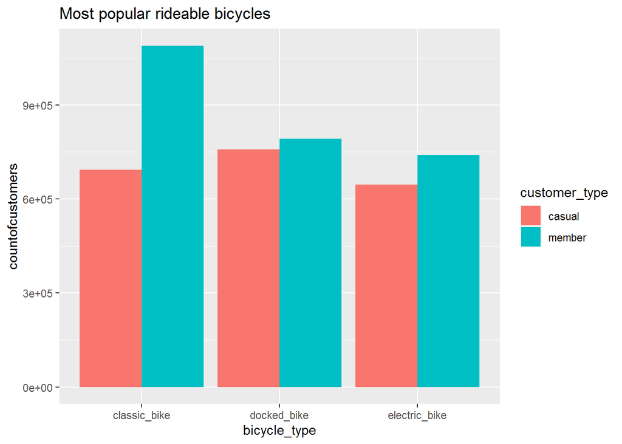

```r
  ggplot(data = t,mapping =  aes(x= bicycle_type, y = countofcustomers,fill = customer_type)) +
  geom_bar( position = "dodge",stat = "identity")+ labs(title = "Most popular rideable bicycles" )
```

## relation_customer_ride_length

### summary

```r
summary(annualtrip$ride_length_min)
```

```
##     Min.  1st Qu.   Median     Mean  3rd Qu.     Max.
##     0.00     7.00    13.00    24.52    24.00 55944.00
```

### pivot tables

```r
 t<- annualtrip  %>%  group_by(customer_type) %>% summarise(count = n(), avg = mean(ride_length_min) ,sum = sum(ride_length_min), sd = sd(ride_length_min) , var=var(ride_length_min))

  # create summary table rows: ride_length_min ,col: customer_type values : count of trips
  t <- qpvt(annualtrip, "ride_length_min","customer_type",  "n()")
  # convert it to dataframe
  relation_customer_ridelength <- t$asDataFrame()

 # replacing null values with 0 so that we can handle data and viz
  relation_customer_ridelength$casual [is.na( relation_customer_ridelength$casual )] <-   0
  relation_customer_ridelength$member [is.na( relation_customer_ridelength$member )] <-   0
  head(relation_customer_ridelength,60)
```

```
##    casual member  Total
## 0   20223  30297  50520
## 1   16885  26695  43580
## 2   16831  65387  82218
## 3   26744 114892 141636
## 4   43017 156692 199709
## 5   55378 164943 220321
## 6   68939 172494 241433
## 7   73356 160549 233905
## 8   79348 154044 233392
## 9   78477 136525 215002
## 10  80009 129367 209376
## 11  75989 115570 191559
## 12  74865 107011 181876
## 13  68971  93266 162237
```

[output cut: 46 more lines]

```r
# write.csv(relation_customer_ridelength,"summary_ridelength_customertype.csv",row.names = TRUE)
```

### plot up to 255 min

[figure not shown]

```r
# when you present all data will be a problem because distribution of ride_length
# one solution is normalization but i have focus on spotlight that's help me discover
# difference between casual and member
# interest area to discover
x1 <- relation_customer_ridelength[c(1:255),]
# we have cast  ride_length_min to integer because it contain Total as char
ggplot(data = x1) + geom_smooth(mapping = aes(x= as.integer(row.names(x1)) ,y= casual,colour ="casual" ))+geom_smooth(mapping = aes(x= as.integer(row.names(x1)) ,y= member,colour  ="member" ) ) + scale_colour_manual("",  breaks = c("casual", "member"),values = c("red", "blue")) + labs(title = "trend users for trips up to 60 min")+ xlab("ride-length-min") +ylab("count of rides")
```

[figure not shown]

```r
x1 <- relation_customer_ridelength[c(255:500),]


ggplot(data = x1) + geom_smooth(mapping = aes(x= as.integer(row.names(x1)) ,y= casual,colour ="casual" ))+geom_smooth(mapping = aes(x= as.integer(row.names(x1)) ,y= member,colour  ="member" ) ) + scale_colour_manual("",  breaks = c("casual", "member"),values = c("red", "blue")) + labs(title = "trend users for trips more than 60 min")+ xlab("ride-length-min") +ylab("count of rides")
```

## relation_weekday_customer

### summary_week

```r
 t<- annualtrip  %>%  group_by(Week_Of_Day) %>%
  summarise( countofrides = n(), sumofrides = sum(ride_length_min),sd = sd(ride_length_min) ,   var=var(ride_length_min))
 ## write.csv(t,"summary_week.csv",row.names = TRUE)
```

### pivot table

```r
  n_week <- qpvt(annualtrip, "Week_Of_Day","customer_type",  "n()")
  n_week <- n_week$asDataFrame()
  n_week <- rename(n_week,count_of_casual = casual)
  n_week <- rename(n_week,count_of_member = member)
  n_week <- rename(n_week,count_of_customer = Total)

 avg_week <- qpvt(annualtrip, "Week_Of_Day","customer_type", c("averageofrides" = "mean(ride_length_min)"))
 avg_week <- avg_week$asDataFrame()

 avg_week <- rename(avg_week,avg_ridelength_of_casual = casual)
 avg_week <- rename(avg_week,avg_ridelength_of_member = member)
 avg_week <- rename(avg_week,avg_ridelength_of_customer = Total)
 week_summary <- data.frame(n_week,avg_week)
 print(week_summary)
```

```
##           count_of_casual count_of_member count_of_customer
## Monday             229626          348732            578358
## Tuesday            223132          380078            603210
## Wednesday          231179          398766            629945
## Thursday           231874          379880            611754
## Friday             302779          388560            691339
## Saturday           485109          395484            880593
## Sunday             392469          330099            722568
## Total             2096168         2621599           4717767
##           avg_ridelength_of_casual avg_ridelength_of_member
## Monday                    36.19168                 14.27501
## Tuesday                   32.66250                 13.88835
## Wednesday                 32.54607                 14.00980
## Thursday                  32.12573                 13.72642
## Friday                    34.85781                 14.47011
## Saturday                  39.61069                 16.21973
## Sunday                    42.56005                 16.76165
## Total                     36.75512                 14.73451
##           avg_ridelength_of_customer
## Monday                      22.97661
## Tuesday                     20.83305
## Wednesday                   20.81229
## Thursday                    20.70033
## Friday                      23.39911
## Saturday                    29.10555
## Sunday                      30.77427
## Total                       24.51857
```

```r
#write.csv(week_summary,"week_summary_ride_customer.csv",row.names = TRUE)
```

### plot count rides during weekdays

```r
 t <- annualtrip %>%  group_by(Week_Of_Day,customer_type) %>% summarise(countofcustomers =n())
```

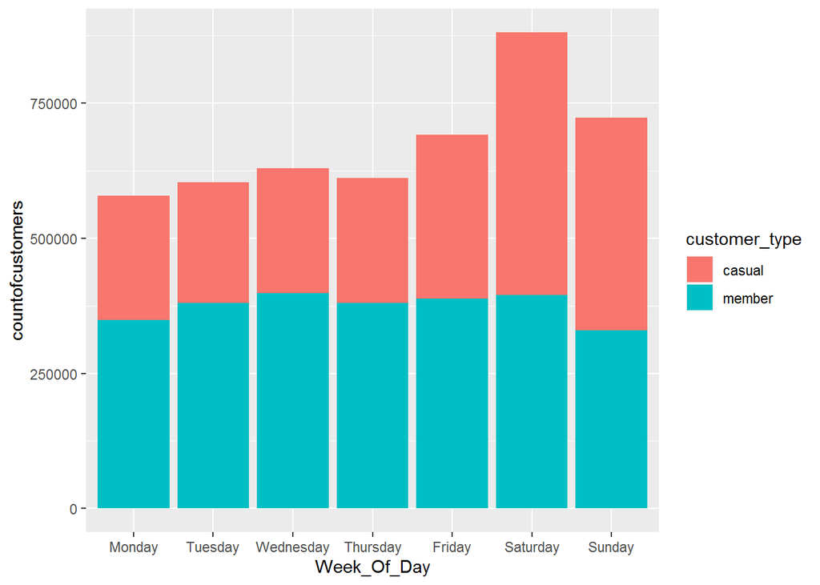

```r
t$Week_Of_Day <- ordered(t$Week_Of_Day, levels=c("Monday", "Tuesday", "Wednesday", "Thursday", "Friday", "Saturday", "Sunday"))


  ggplot(data = t , mapping = aes(x= Week_Of_Day, y = countofcustomers,fill= customer_type)) +
  geom_bar( stat = "identity")
```

### plot avg_ride_length during weekdays

```r
 t <- annualtrip %>%  group_by(Week_Of_Day,customer_type) %>% summarise(mean =mean(ride_length_min))
```

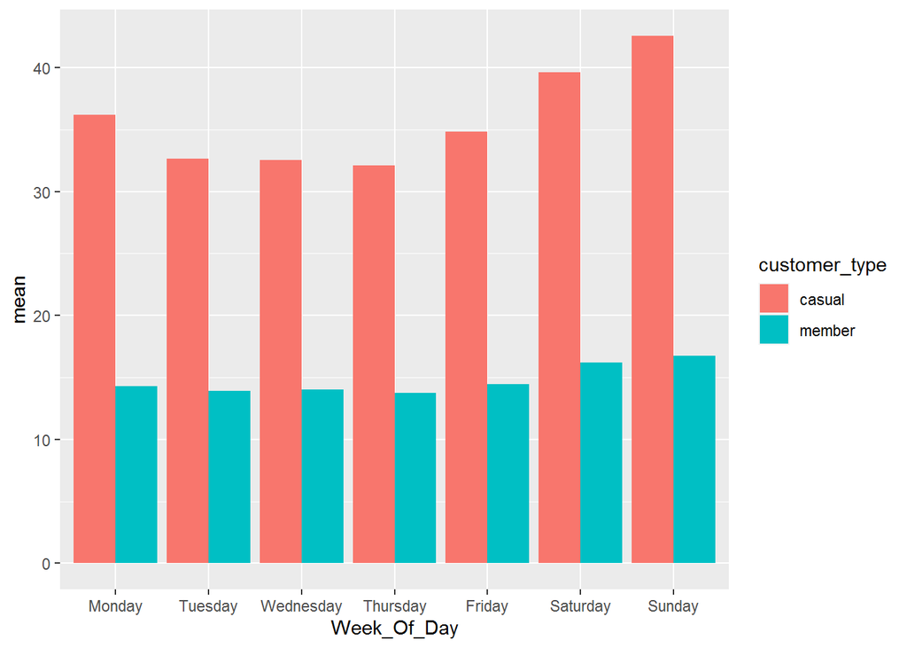

```r
t$Week_Of_Day <- ordered(t$Week_Of_Day, levels=c("Monday", "Tuesday", "Wednesday", "Thursday", "Friday", "Saturday", "Sunday"))
  ggplot(data = t , mapping = aes(x= Week_Of_Day, y = mean,fill= customer_type)) +
  geom_bar(position = "dodge" , stat = "identity")
```

```r
  #title("average riding for customer during week")
```

casual are active in friday and weekends member are active in workday

## traffic and relations

what we need ? station_name lat,lng traffic_begin_casual traffic_begin_member traffic_begin_total traffic_end_casual traffic_end_member traffic_end_total total_traffic_member total_traffic_casual total_traffic

### summary stations

```r
trafficstart <- annualtrip %>% group_by(start_station_id) %>% drop_na() %>% count()
trafficend <- annualtrip %>% group_by(end_station_id) %>%drop_na()%>%  count()

id <- c(1:731,0)
trafficstartbycustomer <- qpvt(annualtrip, "start_station_id", "customer_type", "n()")
trafficstartbycustomer <- trafficstartbycustomer$asDataFrame()
trafficstartbycustomer <- data.frame(id,trafficstartbycustomer)
trafficstartbycustomer <- rename(trafficstartbycustomer,traffic_begin_casual = casual)
trafficstartbycustomer <- rename(trafficstartbycustomer,traffic_begin_member = member)
trafficstartbycustomer <- rename(trafficstartbycustomer,traffic_begin = Total)

trafficendbycustomer <- qpvt(annualtrip, "end_station_id", "customer_type", "n()")
trafficendbycustomer <- trafficendbycustomer$asDataFrame()
trafficendbycustomer <- data.frame(id,trafficendbycustomer)
trafficendbycustomer <- rename(trafficendbycustomer,traffic_end_casual = casual)
trafficendbycustomer <- rename(trafficendbycustomer,traffic_end_member = member)
trafficendbycustomer <- rename(trafficendbycustomer,traffic_end = Total)

stations <- rbind(stations,0)  # only to merge process
summary_stations <- data.frame(stations$id ,stations$end_station_name ,stations$lat,stations$lng ,stations$traffic ,trafficstartbycustomer$traffic_begin_casual,trafficstartbycustomer$traffic_begin_member,trafficstartbycustomer$traffic_begin,trafficendbycustomer$traffic_end_casual,trafficendbycustomer$traffic_end_member,trafficendbycustomer$traffic_end)
head(summary_stations)
```

```
##   stations.id  stations.end_station_name stations.lat stations.lng
## 1           1    Streeter Dr & Grand Ave     41.89228    -87.61205
## 2           2  Lake Shore Dr & Monroe St     41.88097    -87.61674
## 3           3        Theater on the Lake     41.92627    -87.63085
## 4           4          Clark St & Elm St     41.90294    -87.63136
## 5           5      Michigan Ave & Oak St     41.90097    -87.62377
## 6           6 Lake Shore Dr & North Blvd     41.91172    -87.62681
##   stations.traffic trafficstartbycustomer.traffic_begin_casual
## 1            66396                                       54238
## 2            42730                                       33472
## 3            40268                                       23429
## 4            39598                                       15253
## 5            38744                                       25690
## 6            38434                                       22203
##   trafficstartbycustomer.traffic_begin_member
```

[output cut: 20 more lines]

```r
 #write.csv(summary_stations,"summary_stations.csv",row.names = FALSE)
```

### plot

in r we can’t provide live graphs only image !!

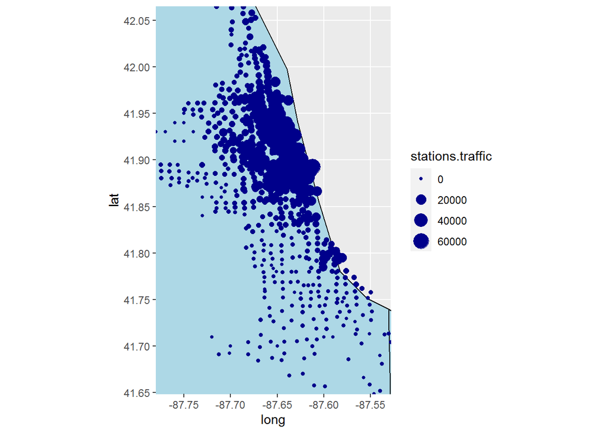

```r
 stat <-  summary_stations[c(1:731),]  # only temp for min and max values
 xmin <- min(stat$stations.lng)
 xmax<- max(stat$stations.lng)
 ymin <- min(stat$stations.lat)
 ymax<- max(stat$stations.lat)
 rm(stat)
MainStates <- map_data("state")
ggplot() +  geom_polygon( data=MainStates, aes(x=long, y=lat, group=group),
                color="black", fill="lightblue" )+
  geom_point(data=summary_stations, aes(x=stations.lng, y= stations.lat,size =stations.traffic),color='darkblue') +geom_sf(color = "black", fill = "lightgreen")+ coord_sf(xlim = c(xmin, xmax), ylim = c(ymin, ymax), expand = FALSE)
```

depend on traffic and previous graphs for traffic movement. where are excepted member and casual to find and traffic is important to locate address of Advertisements

## monitoring months

we don’t need to monitoring seasons we can from month table do it or conclusion from months viz

### summary month

```r
t<- annualtrip  %>%  group_by(month) %>%
  summarise( countofrides = n(), sumofrides = sum(ride_length_min),sd = sd(ride_length_min) ,   var=var(ride_length_min))
  write.csv(t,"summary_month.csv",row.names = TRUE)
```

### pivot month

```r
  n_month <- qpvt(annualtrip, "month","customer_type",  "n()")
  n_month <- n_month$asDataFrame()
  n_month <- rename(n_month,count_of_casual = casual)
  n_month <- rename(n_month,count_of_member = member)
  n_month <- rename(n_month,count_of_customer = Total)

  avg_month <- qpvt(annualtrip, "month","customer_type", c("averageofrides" = "mean(ride_length_min)"))
 avg_month <- avg_month$asDataFrame()



 avg_month <- rename(avg_month,avg_ridelength_of_casual = casual)
 avg_month <- rename(avg_month,avg_ridelength_of_member = member)
 avg_month <- rename(avg_month,avg_ridelength_of_customer = Total)
 month_summary <- data.frame(n_month,avg_month)
 print(month_summary)
```

```
##           count_of_casual count_of_member count_of_customer
## January             18117           78710             96827
## February            10130           39488             49618
## March               84023          144453            228476
## April              136587          200602            337189
## May                256886          274690            531576
## June               370636          358893            729529
## July               438748          378901            817649
## August             288586          330895            619481
## September          230049          300718            530767
## October            144511          242191            386702
## November            87901          170921            258822
## December            29994          101137            131131
## Total             2096168         2621599           4717767
##           avg_ridelength_of_casual avg_ridelength_of_member
## January                   25.68681                 12.87110
## February                  49.37927                 18.02325
## March                     38.16252                 13.96925
## April                     38.02464                 14.69017
## May                       38.23371                 14.63846
## June                      37.12450                 14.67726
## July                      32.73174                 14.23031
## August                    44.93884                 16.83483
## September                 38.22286                 15.54068
## October                   30.25671                 14.04763
## November                  31.82078                 13.58787
## December                  26.85197                 12.74860
## Total                     36.75512                 14.73451
##           avg_ridelength_of_customer
## January                     15.26901
## February                    24.42489
## March                       22.86642
## April                       24.14239
## May                         26.04095
## June                        26.08154
## July                        24.15812
## August                      29.92712
## September                   25.37176
## October                     20.10498
## November                    19.78012
## December                    15.97451
## Total                       24.51857
```

```r
#write.csv(month_summary,"month_summary_ride_customer.csv",row.names = TRUE)
```

### plot Total rides per month

```r
 t <- annualtrip %>%  group_by(month,customer_type) %>% summarise(countofcustomers =n()) %>%
 arrange(match(month, month.name))
```

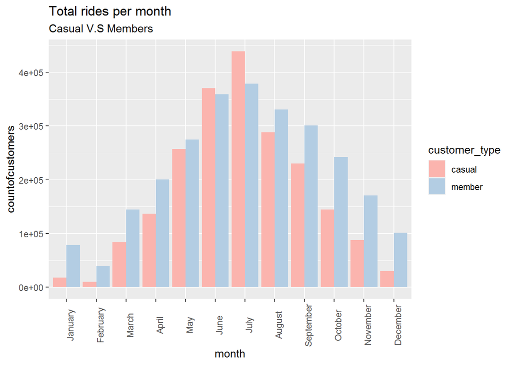

```r
t$month <- ordered(t$month, levels=c("January", "February", "March", "April", "May", "June", "July", "August", "September", "October", "November", "December"))
  ggplot(data = t , mapping = aes(x= month, y = countofcustomers,fill= customer_type)) +
  geom_bar(position = "dodge", stat = "identity") + theme(axis.text.x = element_text(angle = 90)) + labs(title = "Total rides per month", subtitle ="Casual V.S Members") + scale_fill_brewer(palette = "Pastel1")
```

### average ride_length per month

```r
 t <- annualtrip %>%  group_by(month,customer_type) %>% summarise(mean =mean(ride_length_min))
```

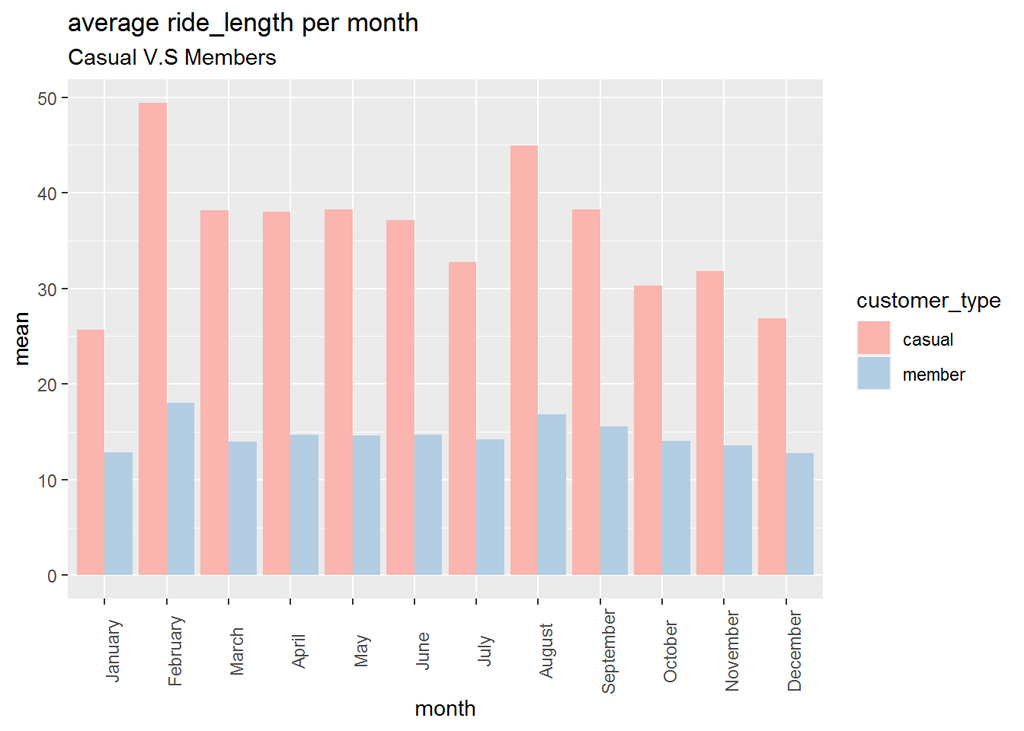

```r
t$month <- ordered(t$month, levels=c("January", "February", "March", "April", "May", "June", "July", "August", "September", "October", "November", "December"))
  ggplot(data = t , mapping = aes(x= month, y = mean,fill= customer_type)) +
  geom_bar(position = "dodge" , stat = "identity") + theme(axis.text.x = element_text(angle = 90)) + labs(title = "average ride_length per month", subtitle ="Casual V.S Members") + scale_fill_brewer(palette = "Pastel1")
```

difference count of rides depend on weahter cold and hot seasons  
7 hot ,2 mild ,3 cold

## total rides during week in month in year

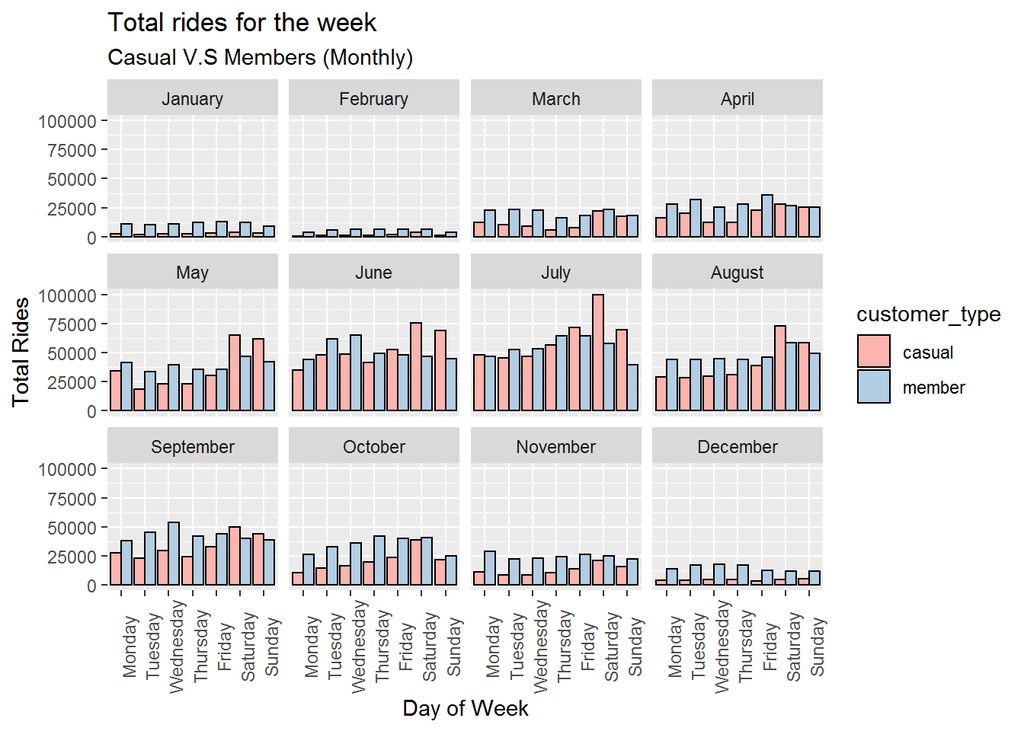

```r
annualtrip %>%
  group_by(Week_Of_Day, month, customer_type) %>%
  summarise(number_of_rides = n()) %>%
  ggplot(aes(x=Week_Of_Day, y = number_of_rides, fill= customer_type)) + geom_col(position = "dodge", colour = "black") + scale_fill_brewer(palette = "Pastel1") + facet_wrap(~month)+ theme(axis.text.x = element_text(angle = 90)) + labs(title = "Total rides for the week", subtitle = "Casual V.S Members (Monthly)")  + ylab("Total Rides") + xlab("Day of Week")
```

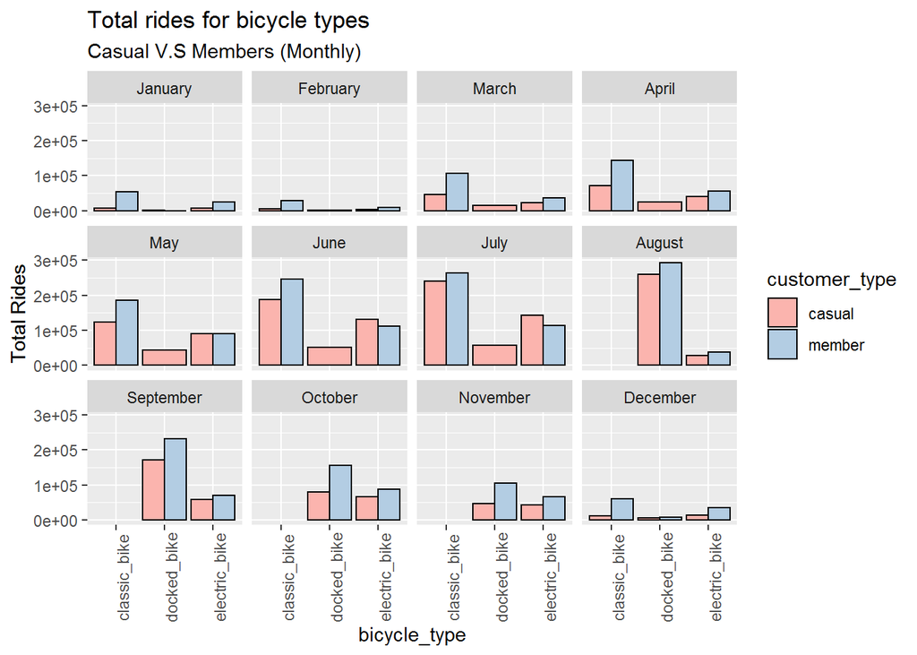

```r
annualtrip %>%
  group_by(bicycle_type, month, customer_type) %>%
  summarise(number_of_rides = n()) %>%
  ggplot(aes(x=bicycle_type, y = number_of_rides, fill= customer_type)) + geom_col(position = "dodge", colour = "black") + scale_fill_brewer(palette = "Pastel1") + facet_wrap(~month)+ theme(axis.text.x = element_text(angle = 90)) + labs(title = "Total rides for bicycle types", subtitle = "Casual V.S Members (Monthly)")  + ylab("Total Rides") + xlab("bicycle_type")
```

## ACT PHASE

### Recommendations

1. schedule good pricing depend on factors (riding time , cold and hot days/month during year)
- make to 15 min with 1 dollar and with more from 15 min 2 dollar.and so day ..month,year
2. we need to discover grow of interest in bicycles types so that we can also make limit on electric bicycle  
   so that we can attract more customer for month,season annual member (need of customers)
3. make this campaign in summer using poster on bicycles where most movement for casual  
   using our app platform to advertise or make survey
4. web campaign isn’t appropriate in this task because they are already customers and big poster in stations that have traffic day  
   say offer “save 70 % pro year with …. unlimited riding …..with special event”
5. provide a new feature in app to customer for examples event,racing,….